# Линейные модели для счетных данных

## Мы рассмотрим

- Варианты анализа для случаев, когда зависимая перменная — счетная величина (целые неотрицательные числа)

### Вы сможете

- Объяснить особенности разных типов распределений, принадлежащих экспоненциальному семейству.
- Построить пуасоновскую и квази-пуассоновскую линейную модель
- Объяснить проблемы, связанные с избыточностью дисперсии в модели
- Построить модель, основанную на отрицательном биномиальном распределении

## Статистические распределения

## Основные распределения для непрерывных данных

- Нормальное распределение (уже знакомо)
- Гамма-распределение

## Нормальное распределение

\[f(y;\mu, \sigma)= \frac {1}{\sigma \sqrt{2 \pi}} e^{-\frac{(y-\mu)^2}{2\sigma^2}}\]

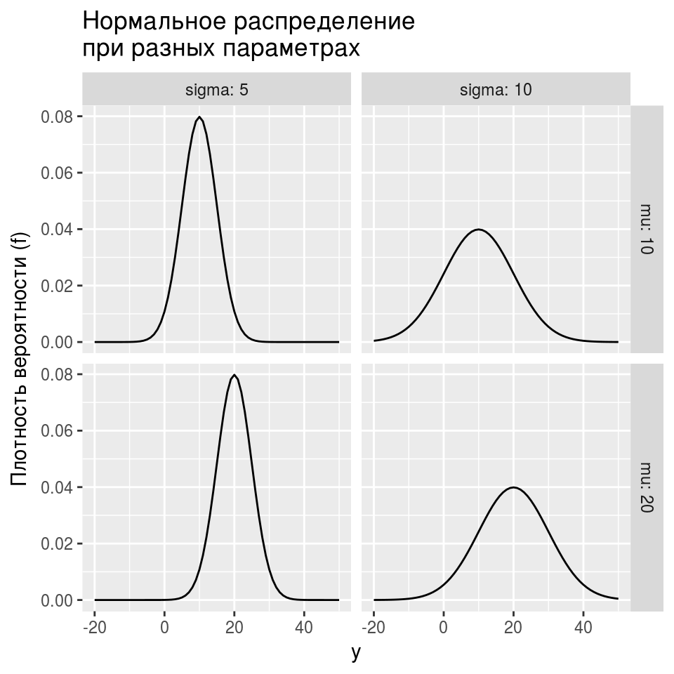

### Два параметра (\(\mu\), \(\sigma\))

Среднее: \(E(Y) = \mu\)

Дисперсия: \(var(Y) = \sigma^2\)

### Пределы варьирования

\(-\infty \le Y \le +\infty\)

## Гамма-распределение

\[f(y; \mu, \nu) = \frac{1}{\Gamma(\nu)}\times (\frac{\nu}{\mu})^{\nu} \times y^{\nu-1} \times e^{\frac{y \times \nu}{\mu}}\]

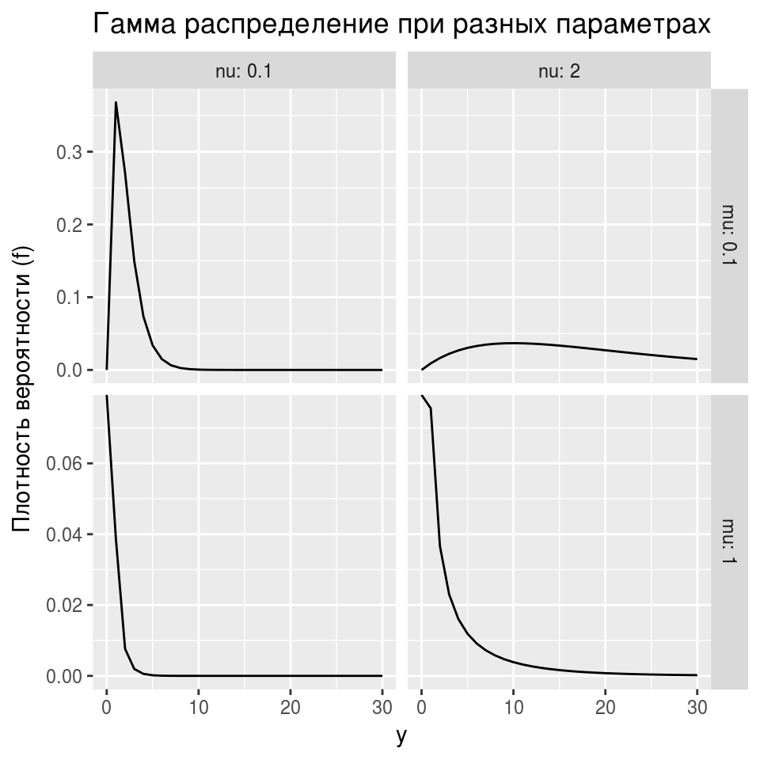

### Два параметра (\(\mu\), \(\nu\))

Среднее: \(E(Y) = \mu\)

Дисперсия: \(var(Y) = \frac {\mu^2}{\nu}\)

Параметр \(\nu\) определяет степень избыточности дисперсии

### Пределы варьирования

\(0 < Y \le +\infty\)

Внимание! \(Y\) строго больше 0

## Распределения для дискретных данных

- Биномиальное распределение (знакомство было в прошлый раз)
- Распределение Пуассона
- Отрицательное биномиальное распределение

## Биномиальное распределение

\[f(y; N, \pi) = \frac{N!}{y! \times (N-y)!} \times \pi^y \times (1 - \pi)^{N-y}\]

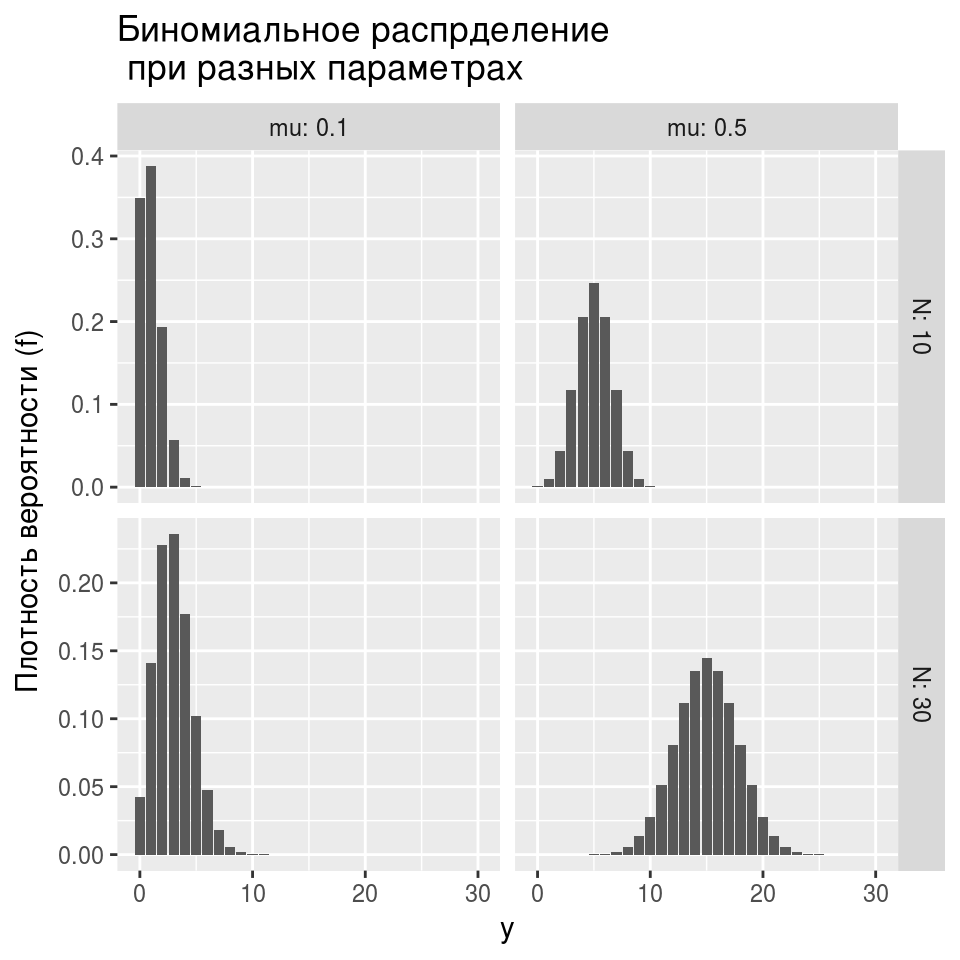

### Два параметра (\(N\), \(\pi\))

Среднее: \(E(Y) = N \times \pi\)

Дисперсия: \(var(Y) = N \times \pi \times (1-\pi)\)

Параметр \(N\) определяет количество объектов в испытании

Параметр \(\pi\) - вероятность события (\(y = 1\))

### Пределы варьирования

\(0 \le Y \le +\infty\), \(Y\) **целочисленные**

## Распределение Пуассона

\[f(y;\mu)= \frac{\mu^y \times e{-\mu}}{y!}\]

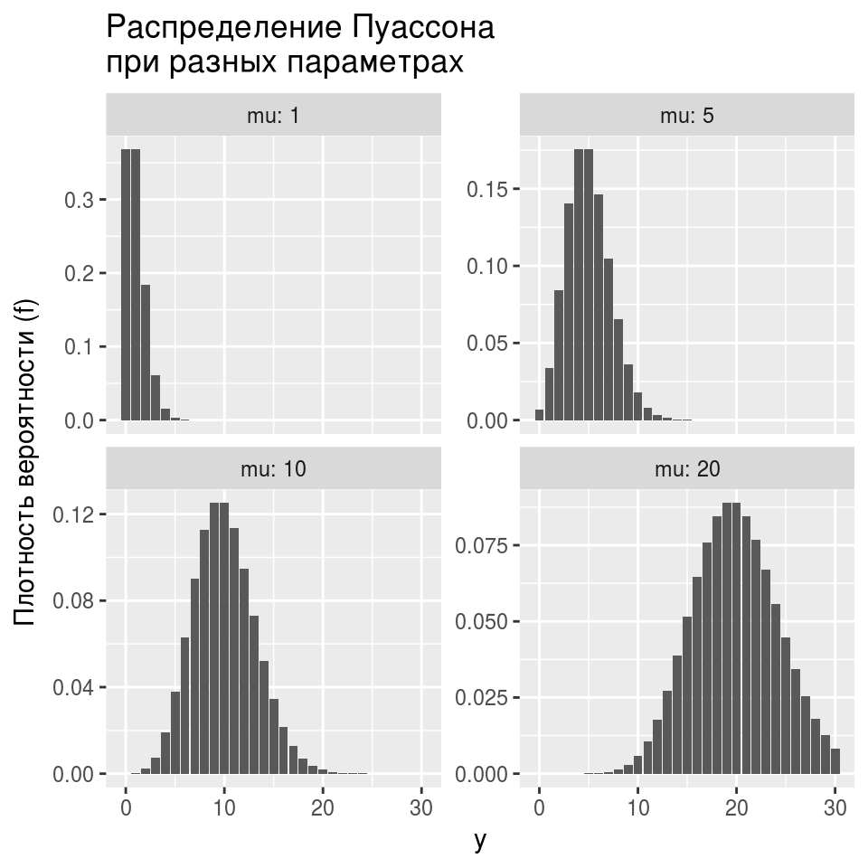

### Один параметр (\(\mu\))

Среднее: \(E(Y) = \mu\)

Дисперсия: \(var(Y) = \mu\)

**Важное свойство**: При увеличении значения \(\mu\) увеличивается размах варьирования

### Пределы варьирования

\(0 \le Y \le +\infty\), \(Y\) **целочисленные**

## Отрицательное биномиальное распределение

\[f(y; k, \mu) = \frac{\Gamma(y + k)}{\Gamma(k) \times \Gamma(y+1)} \times (\frac{k}{\mu + k})^k \times (1 - \frac{k}{\mu + k})^y\]

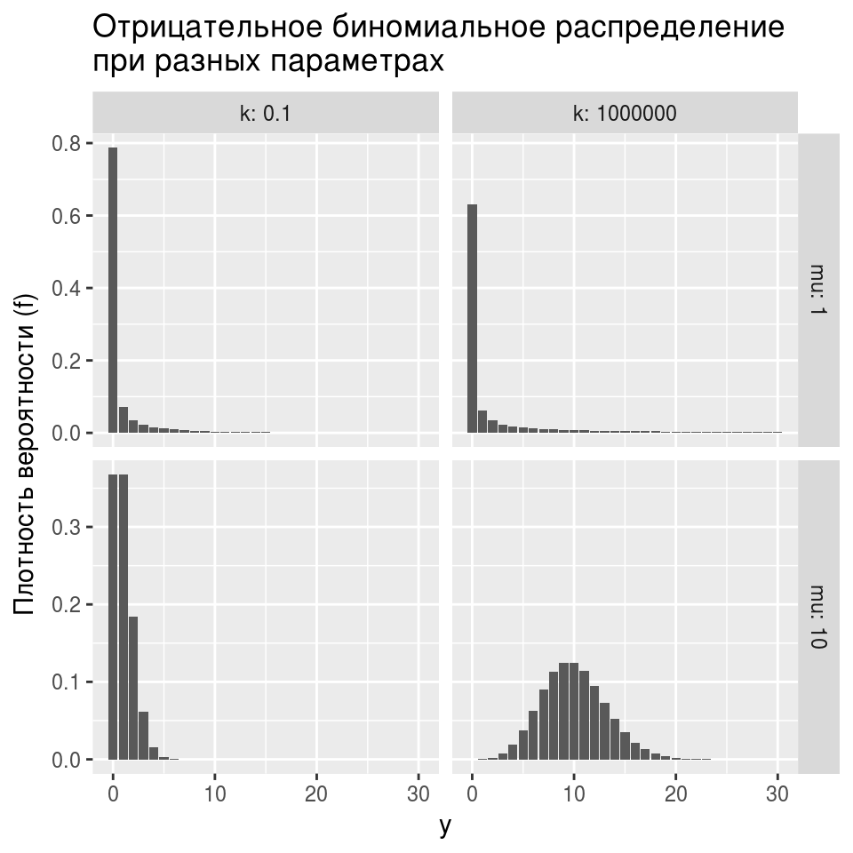

Это смесь Пуассоновского и Гамма распределений: \(Y\) подчиняется распределению Пуассона с Гамма-распределенным \(\mu\).

### Два параметра (\(\mu\), \(k\))

Среднее: \(E(Y) = \mu\)

Дисперсия: \(var(Y) = \mu + \frac {\mu^2}{k}\)

Параметр \(k\) определяет степень избыточности дисперсии.

**Свойство**: Приближается к распр. Пуассона при очень больших \(k\).

### Пределы варьирования

\(0 \le Y \le +\infty\), \(Y\) **целочисленные**

## Распределение зависимой переменной и линия регрессии

## Связующая функция (Link function)

Предсказаные значения, т.е. \(E(Y_i) = \mu_i\), лежат на линии регрессии.

Для линейных моделей с нормальным распределением отклика связь между \(E(Y_i)\) и предикторами линейна.

Для других типов распределений эта связь нелинейна.

Функция, при помощи которой удается линеаризовать связь между \(E(Y_i)\) и предикторами называется *связующей функцией*. (Иными словами, связующая функция описывает связь между \(\mu_i\) и значениями предикторов в виде линейной функции).

## Наиболее распространенные (канонические) связующие функции

| Характер величин | Распределение | Связующая функция (link function) |
| --- | --- | --- |
| Непрерывные величины, потенциально варьирующие в пределах \(-\infty , + \infty\) | Гауссовское (Нормальное) | identity \(X\beta = \mu\) |
| Бинарные величины (1; 0), или количество (доля) объектов, относящихся к одному из двух классов | Биномиальное распределение | logit \(X\beta = ln(\frac{\mu}{1 - \mu})\) |
| Счетные величины (0, 1, 2, 3…) | Распределение Пуассона или Отрицательное биномиальное распределение | log \(X\beta = ln(\mu)\) |

Есть и другие, неканонические связующие функции

## Связующая функция (Link function)

В случае с нормальным распределением, предсказанные значения лежат на прямой линии, связывающей значения предиктора \(x_i\) и предсказанное значение \(\mu_i\).

Т.к. зависимость и так линейная, то связующая функция не выполняет никакой работы — описывает идентичность (`link = "identity"`).

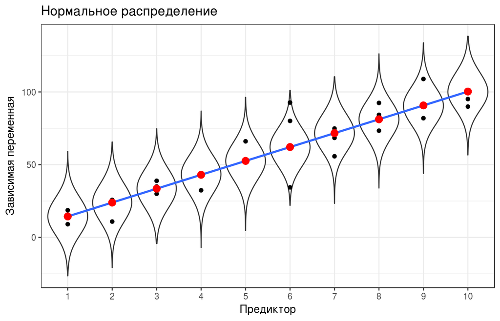

## Связующая функция (Link function)

В случае с биномиальным распределением, предсказанные значения лежат на логистической кривой, связывающей значения предиктора \(x_i\) и предсказанное значение \(\mu_i\).

Связующая функция логит (`link = "logit"`) линеаризует эту зависимость.

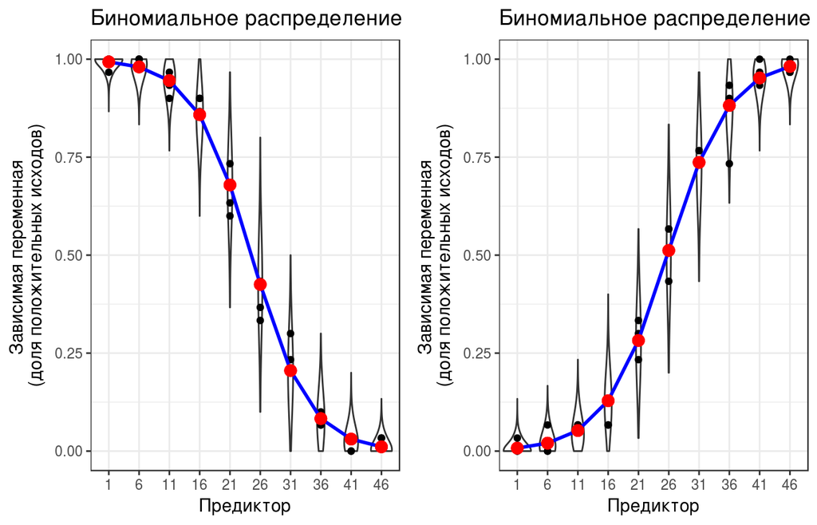

## Связующая функция (Link function)

В случае с пуассоновским распределением, предсказанные значения лежат на экспоненциальной кривой, связывающей значения предиктора \(x_i\) и предсказанное значение \(\mu_i\).

Связующая функция логарифм (`link = "log"`) линеаризует эту зависимость.

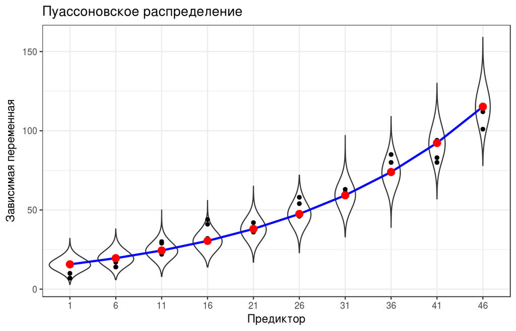

## Пример

## Пример: Гадючий лук, копеечник и визиты опылителей

[Гадючий лук](https://ru.wikipedia.org/wiki/Гадючий_лук_хохлатый) (*Leopoldia comosa*, сем. спаржевые) — представитель родной флоры острова Менорка (Балеарские острова, Средиземное море). В 18-19вв на остров завезли [копеечник венечный](https://ru.wikipedia.org/wiki/Копеечник_венечный) (*Hedysarum coronarium*, сем. бобовые), который быстро натурализовался. Оба вида цветут одновременно и нуждаются в опылении насекомыми.

Как зависит опыление гадючьего лука от присутствия вида-вселенца и разнообразия флоры в ближайшей окрестности (Montero-Castaño, Vilà, 2015)?

[figure not shown]

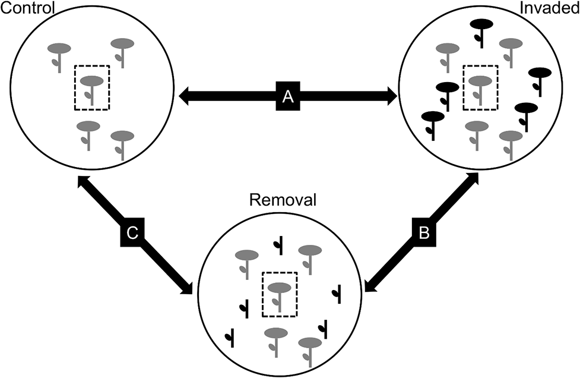

[figure not shown]

Muscari à toupet (Muscari comosum), Dordogne, France — Père Igor  
Fig.2 из [Montero-Castaño, Vilà, 2015](https://doi.org/10.1371/journal.pone.0128595)  
French-honeysuckle. Close to Santadi Basso, Sardinia, Italy — Hans Hillewaert

## Данные

- `Visits` — число визитов всех опылителей на цветок *Leopoldia*
- `Treatment` — `Invaded` — *Leopoldia* в смеси с видом-вселенцем *Hedysarum*; `Removal` — *Leopoldia* в смеси с видом-вселенцем с удаленными цветками; `Control` — *Leopoldia* без вида вселенца
- `DiversityD_1` — Разнообразие флоры — \(exp(H’)\), где \(H'\) — индекс Шеннона, расчитанный с использованием натурального логарифма
- `Flowers` — число цветков *Leopoldia*
- `Hours` — продолжительность наблюдений

```r
library(readxl)
pol <- read_excel("data/Pollinators_Montero-Castano, Vila, 2015.xlsx", sheet = 1)
head(pol)
```

```
## # A tibble: 6 x 10
##   Individual Treatment DiversityD_1 Visits Visits_NO_Apis Total_1
##        <dbl>     <chr>        <dbl>  <dbl>          <dbl>   <dbl>
## 1          1   Removal         2.66      4              4   53.90
## 2          2   Removal         1.00      6              6    2.45
## 3          3   Removal         1.44      5              5   41.65
## 4          4   Removal         2.21      1              1   58.80
## 5          5   Removal         2.83      6              6   19.60
## 6          6   Removal         2.40      2              2   78.40
## # ... with 4 more variables: Fruit <dbl>, No_Fruit <dbl>,
## #   Flowers <dbl>, Hours <dbl>
```

[Montero-Castaño A., Vilà M. 2015](https://doi.org/10.1371/journal.pone.0128595)

## Знакомство с данными

Есть ли пропущенные значения?

```r
sum(is.na(pol))
```

```
## [1] 0
```

Сколько площадок в каждом тритменте?

```r
table(pol$Treatment)
```

```
##
## Control Invaded Removal
##      14      11      18
```

## Знакомство с данными

Как распределено число визитов насекомых?

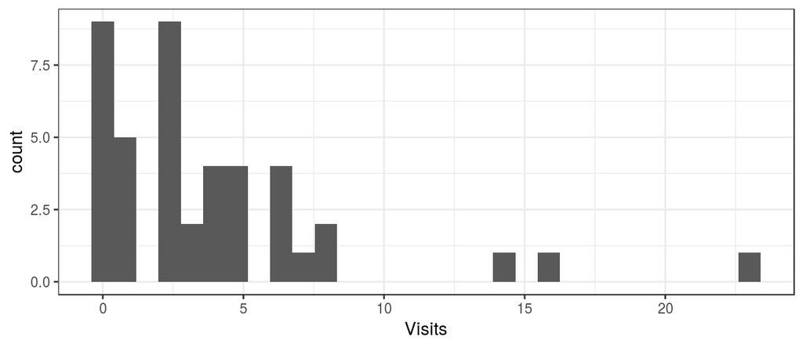

```r
library(ggplot2)
ggplot(pol, aes(x = Visits)) + geom_histogram()
```

## Знакомство с данными

Нет ли выбросов?

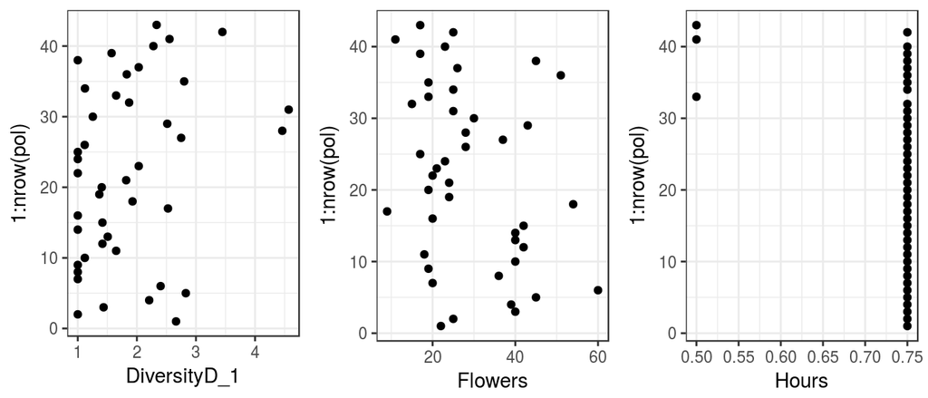

```r
gg_dot <- ggplot(pol, aes(y = 1:nrow(pol))) + geom_point()
library(gridExtra)
grid.arrange(gg_dot + aes(x = DiversityD_1),
             gg_dot + aes(x = Flowers),
             gg_dot + aes(x = Hours),
             nrow = 1)
```

- Выбросов нет

## Простая линейная модель

## GLM с Гауссовым распределением отклика

\(Visits_i \sim N(\mu_i, \sigma)\)

\(E(Visits_i) = mu_i\), \(var(Visits_i) = \sigma\)

Функция связи — идентичность, т.е.

\(\mu_i = b_0 + b_1 TreatmentInvaded + b_2 TreatmentRemoval +\)  
\(+ b_3 DiversityD1 + b_4 Flowers + b_5 Hours\)

## Что будет, если мы (ошибочно) подберем простую линейную модель?

```r
M0 <- glm(Visits ~ Treatment + DiversityD_1 + Flowers + Hours, data = pol)
## Результаты
summary(M0)
```

```
##
## Call:
## glm(formula = Visits ~ Treatment + DiversityD_1 + Flowers + Hours,
##     data = pol)
##
## Deviance Residuals:
##    Min      1Q  Median      3Q     Max
## -7.432  -2.361  -0.393   1.034  13.238
##
## Coefficients:
##                  Estimate Std. Error t value Pr(>|t|)
## (Intercept)       -3.2545     7.7310   -0.42    0.676
## TreatmentInvaded   2.8908     1.7626    1.64    0.109
## TreatmentRemoval  -1.0617     1.6776   -0.63    0.531
## DiversityD_1      -1.2041     0.7851   -1.53    0.134
## Flowers            0.1439     0.0585    2.46    0.019 *
## Hours              6.6546    10.6424    0.63    0.536
## ---
## Signif. codes:  0 '***' 0.001 '**' 0.01 '*' 0.05 '.' 0.1 ' ' 1
##
## (Dispersion parameter for gaussian family taken to be 17.4)
##
##     Null deviance: 891.86  on 42  degrees of freedom
## Residual deviance: 644.61  on 37  degrees of freedom
## AIC: 252.4
##
## Number of Fisher Scoring iterations: 2
```

## Анализ девиансы для гауссовой модели

К какому бы мы пришли выводу, глядя на этот анализ?

```r
library(car)
Anova(M0)
```

```
## Analysis of Deviance Table (Type II tests)
##
## Response: Visits
##              LR Chisq Df Pr(>Chisq)
## Treatment        5.71  2      0.058 .
## DiversityD_1     2.35  1      0.125
## Flowers          6.04  1      0.014 *
## Hours            0.39  1      0.532
## ---
## Signif. codes:  0 '***' 0.001 '**' 0.01 '*' 0.05 '.' 0.1 ' ' 1
```

- Число визитов опылителей на цветки гадючьего лука
- НЕ зависит от присутствия вида вселенца и его цветов
- НЕ зависит от разнообразия флоры на участке
- зависит от числа цветов самого гадючьего лука
- Можем ли мы доверять этим результатам? Пока не известно.

## Визуализируем предсказания простой линейной модели

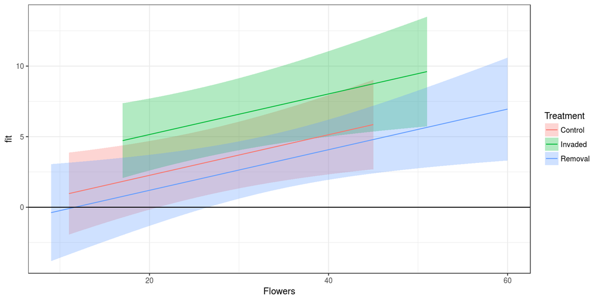

## Код для графика

```r
library(plyr)
NewData <- ddply(.data = pol, .variables = .(Treatment),
    .fun = summarise, Flowers = seq(min(Flowers), max(Flowers),
        length = 100))
NewData$DiversityD_1 = mean(pol$DiversityD_1)
NewData$Hours = mean(pol$Hours)
# модельная матрица
X <- model.matrix(~Treatment + DiversityD_1 + Flowers +
    Hours, data = NewData)
# коэффициенты
betas <- coef(M0)
# предсказанные значения
NewData$mu <- X %*% betas  # в масштабе функции связи
NewData$fit <- NewData$mu  # в масштабе значений отклика
# стандартные ошибки
NewData$SE <- sqrt(diag(X %*% vcov(M0) %*% t(X)))
# доверительный интервал
NewData$upr <- NewData$mu + 1.96 * NewData$SE
NewData$lwr <- NewData$mu - 1.96 * NewData$SE
# график предсказаний
ggplot(NewData, aes(x = Flowers, y = fit, group = Treatment)) +
    geom_ribbon(aes(ymin = lwr, ymax = upr, fill = Treatment),
        alpha = 0.3) + geom_line(aes(colour = Treatment)) +
    geom_hline(yintercept = 0)
```

## Задание 1

Постройте график пирсоновских остатков этой модели.

Какие нарушения условий применимости вы на нем увидите?

Дополните код

```r
# Данные для анализа остатков
M0_diag <- data.frame(.fitted = ,
                      .pears_resid = )
# График остатков
ggplot(M0_diag, aes(x=, y = )) +
  geom_ + geom_(yintercept = 0) +
  geom_(se = FALSE, method = "loess")
```

## Решение

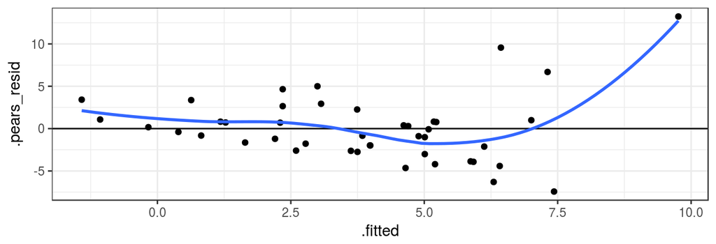

```r
# Данные для анализа остатков
M0_diag <- data.frame(.fitted = predict(M0, type = "response"),
                      .pears_resid = residuals(M0, type = "pearson"))
# График остатков
ggplot(M0_diag, aes(x=.fitted, y = .pears_resid)) +
  geom_point() + geom_hline(yintercept = 0) +
  geom_smooth(se = FALSE, method = "loess")
```

- Гетерогенность дисперсий остатков
- Отрицательные предсказания

## Два способа решения проблем с моделью

1. Плохой способ: провести логарифмирование зависимой переменной и построить модель для логарифмированных величин.
2. Лучше построить модель, основанную на распределении Пуассона.

## GLM с Пуассоновским распределением отклика

## GLM с Пуассоновским распределением отклика

\(Visits_i \sim Poisson(\mu_i)\)

\(E(Visits_i) = mu_i\), \(var(Visits_i) = mu_i\)

Функция связи — логарифм, т.е.

\(\ln(\mu_i) = b_0 + b_1 TreatmentInvaded + b_2 TreatmentRemoval +\)  
\(+ b_3 DiversityD1 + b_4 Flowers + b_5 Hours\)

## GLM с Пуассоновским распределением отклика

```r
M1 <- glm(Visits ~ Treatment + DiversityD_1 + Flowers + Hours, data = pol,  family = "poisson")
## Результаты
summary(M1)
```

```
##
## Call:
## glm(formula = Visits ~ Treatment + DiversityD_1 + Flowers + Hours,
##     family = "poisson", data = pol)
##
## Deviance Residuals:
##    Min      1Q  Median      3Q     Max
## -4.067  -1.319  -0.352   0.707   3.235
##
## Coefficients:
##                  Estimate Std. Error z value    Pr(>|z|)
## (Intercept)      -2.66091    2.17444   -1.22     0.22106
## TreatmentInvaded  0.71342    0.21416    3.33     0.00086 ***
## TreatmentRemoval -0.21538    0.22265   -0.97     0.33337
## DiversityD_1     -0.45740    0.12859   -3.56     0.00037 ***
## Flowers           0.03731    0.00683    5.46 0.000000048 ***
## Hours             4.68669    2.90325    1.61     0.10646
## ---
## Signif. codes:  0 '***' 0.001 '**' 0.01 '*' 0.05 '.' 0.1 ' ' 1
##
## (Dispersion parameter for poisson family taken to be 1)
##
##     Null deviance: 189.75  on 42  degrees of freedom
## Residual deviance: 119.88  on 37  degrees of freedom
## AIC: 238.8
##
## Number of Fisher Scoring iterations: 6
```

## Уравнение модели с Пуассоновским распределением отклика

\(Visits_i ~ Poisson(\mu_i)\)

\(E(Visits_i) = mu_i\), \(var(Visits_i) = mu_i\)

\(\ln(\mu_i) = -2.66 + 0.71 TreatmentInvaded - 0.22 TreatmentRemoval -\)  
\(- 0.46 DiversityD1 + 0.04 Flowers + 4.69 Hours\)

## Анализ девиансы для Пуассоновской модели

К какому бы мы пришли выводу, глядя на этот анализ?

```r
Anova(M1)
```

```
## Analysis of Deviance Table (Type II tests)
##
## Response: Visits
##              LR Chisq Df  Pr(>Chisq)
## Treatment       25.41  2 0.000003037 ***
## DiversityD_1    14.43  1     0.00015 ***
## Flowers         28.79  1 0.000000081 ***
## Hours            3.76  1     0.05261 .
## ---
## Signif. codes:  0 '***' 0.001 '**' 0.01 '*' 0.05 '.' 0.1 ' ' 1
```

- Число визитов опылителей на цветки гадючьего лука
- зависит от присутствия вида вселенца и его цветов
- зависит от разнообразия флоры на данном участке
- зависит от числа цветов самого гадючьего лука
- Можем ли мы доверять этим результатам? Пока не известно.

## Задание 2

Постройте график предсказаний модели

```r
NewData <- ddply(
  .data = , .variables = .(), .fun = summarise,
  DiversityD_1 = seq(min(), max(), length = 100))
NewData$Flowers = mean(pol$Flowers)
NewData$Hours = mean(pol$Hours)
# модельная матрица
X <- model.matrix(, data = NewData)
# коэффициенты
betas <-
# предсказанные значения
NewData$mu <-       # в масштабе функции связи
NewData$fit <-  # в масштабе значений отклика
# стандартные ошибки
NewData$SE <- sqrt(diag(X %*% vcov(M1) %*% t(X)))
# доверительный интервал в масштабе значений отклика
NewData$upr <- (NewData$mu + 1.96 * NewData$SE)
NewData$lwr <- (NewData$mu - 1.96 * NewData$SE)
# график предсказаний
ggplot(NewData, aes(x = , y = , group = Treatment)) +
  geom_ribbon(aes(ymin = lwr, ymax = upr, fill = ), alpha = 0.3) +
  geom_line(aes(colour = )) +
  geom_hline(yintercept = 0)
```

## Визуализируем предсказания модели с Пуассоновским распределением отклика

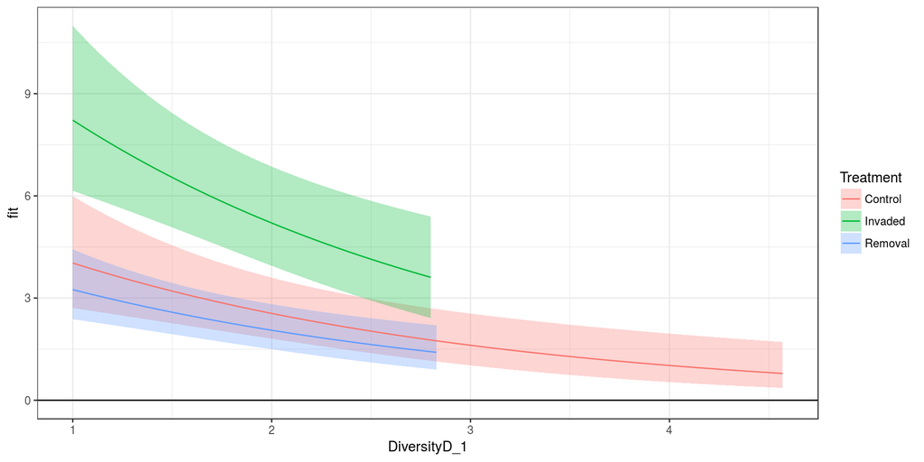

## Код для графика

```r
NewData <- ddply(.data = pol, .variables = .(Treatment),
    .fun = summarise, DiversityD_1 = seq(min(DiversityD_1),
        max(DiversityD_1), length = 100))
NewData$Flowers = mean(pol$Flowers)
NewData$Hours = mean(pol$Hours)
# модельная матрица
X <- model.matrix(~Treatment + DiversityD_1 + Flowers +
    Hours, data = NewData)
# коэффициенты
betas <- coef(M1)
# предсказанные значения
NewData$mu <- X %*% betas  # в масштабе функции связи
NewData$fit <- exp(NewData$mu)  # в масштабе значений отклика
# стандартные ошибки
NewData$SE <- sqrt(diag(X %*% vcov(M1) %*% t(X)))
# доверительный интервал
NewData$upr <- exp(NewData$mu + 1.96 * NewData$SE)
NewData$lwr <- exp(NewData$mu - 1.96 * NewData$SE)
# график предсказаний
ggplot(NewData, aes(x = DiversityD_1, y = fit, group = Treatment)) +
    geom_ribbon(aes(ymin = lwr, ymax = upr, fill = Treatment),
        alpha = 0.3) + geom_line(aes(colour = Treatment)) +
    geom_hline(yintercept = 0)
```

## Диагностика модели

### График остатков

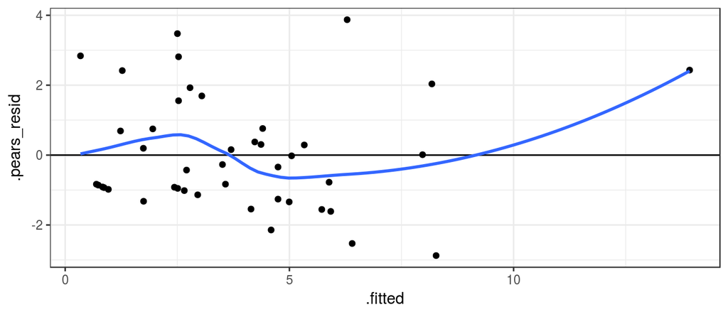

```r
M1_diag <- data.frame(.fitted = predict(M1, type = "response"),
                      .pears_resid = residuals(M1, type = "pearson"))
ggplot(M1_diag, aes(x=.fitted, y = .pears_resid)) + geom_point() +
  geom_hline(yintercept = 0) + geom_smooth(se = FALSE, method = "loess")
```

## Проблема избыточности дисперсии (overdispersion)

Если данные подчиняются распределению Пуассона, то

- Среднее: \(E(Y) = \mu\)
- Дисперсия: \(var(Y) = \mu\)

То есть, дисперсия должна быть равна среднему значению.

Если это нарушается, то мы не можем доверять результатам, так как модель, основанная на Пуассоновском распределении, применяется к данным, которые не подчиняются этому распределению.

## Проверка на сверхдисперсию

```r
pear_res <- resid(M1, type = "pearson") # Пирсоновские остатки
p <- length(coef(M1))                   # число параметров в модели
N <- nrow(model.frame(M1)) # объем выборки
df <- N - p       # число степеней свободы
Overdisp <- sum(pear_res^2) / df

Overdisp
```

```
## [1] 3.02
```

- Избыточность дисперсии есть! Дисперсия в 3 раза выше среднего

## Если есть избыточность дисперсии, то

### Доверительные интервалы будут занижены

Если предполагать, что данные подчиняются распределению Пуассона (среднее \(E(Y) = \mu\), дисперсия — \(var(Y) = \mu\)), то \(var(\bar Y) = {\mu} / n\) и доверительный интервал к среднему будет оценен как \(\bar Y \pm z_{\alpha/2}\sqrt {var(\bar Y)}\).

Если на самом деле дисперсия в \(\varphi\) раз больше среднего (\(\varphi > 1\)): \(var^*(Y) = \varphi\mu\)

Тогда на самом деле \(var(\bar Y) = {\varphi\mu} / n\), а доверительный интервал к среднему должен быть в \(\sqrt\varphi\) раз больше: \(\bar Y \pm z_{\alpha/2}\sqrt {\varphi~var(\bar Y)}\).

### Стандартные ошибки будут занижены

(аналогично предыдущему пункту)

### Тесты, основанные на сравнении правдоподобий будут давать смещенные результаты

Т.к. на самом деле соотношение девианс будет подчиняться не \(\chi^2\)-распределению, а масштабированному \(\chi^2\)-распределению

## Причины избыточности дисперсии

1. Мнимая избыточность дисперсии
   - Наличие выбросов
   - В модель не включен важный предиктор или взаимодействие предикторов
   - Наличие внутригрупповых корреляций (нарушение независимости выборок)
   - Нелинейный характер взаимосвязи между ковариатами и зависимой переменной
   - Неверно выбрана связывающая функция
   - Количество нулей больше, чем предсказывает выбранное распределение (Zero inflation)
2. Истинная избыточность дисперсии, как следствие природы данных

## Как бороться с избыточностью дисперсии

Если избыточнсть дисперсии *мнимая*, то ее надо устранить, введя в модель соответствующие изменения

Если избыточность дисперсии *истинная*, то необходима более серьезная коррекция модели:

- Можно построить квази-пуассоновскую модель
- Можно построить модель, основанную на отрицательном биномиальном распределении

## Квазипуассоновская модель

## Квази-пуассоновские модели

Единственное отличие от пуассоновской модели в том, что в квази-пуассоновских моделях вводится поправка для связи дисперсии и среднего

- Среднее: \(E(Y) = \mu\)
- Дисперсия: \(var(Y) = \varphi \times \mu\)

Величина \(\varphi\) показывает во сколько раз дисперсия превышает среднее

Вот такой вариант оценки используется в R (рекомендован McCullagh, Nelder, 1989):

\[\varphi = \frac{var(Y)}{\mu}=\frac {\frac{\sum{(\epsilon_i)^2}}{N - p}} {\mu} = \frac{\sum{(\epsilon_{pearson})^2}}{N - p}\]

Квазипуассоновская модель, по сути, по-прежнему пуассоновская, но стандартные ошибки оценок параметров домножаются на \(\sqrt{\varphi}\)

## Особенности работы с квази-моделями

1.В тестах параметров используются \(t\)-тесты (и \(t\)-распределение) вместо \(z\) тестов (и стандартного нормального распределения)

2.Для квази-пуассоновских моделей не определена функция максимального правдоподобия, поэтому нельзя вычислить AIC (но иногда считают квази-AIC = QAIC)

3.Для тестов изменения девиансы используются \(F\)-тесты

\[F = \frac{\Delta/d} {\varphi}\] Эта \(F\)-статистика подчиняется \(F\)-распределению со степенями свободы \(d\) и \(df\)

- \(\Delta\) — разница девианс
- \(d\) — разница числа параметров сравниваемых моделей
- \(df\) — остаточное число степеней свободы для более полной модели

## Квазипуассоновская модель

```r
M2 <- glm(Visits ~ Treatment + DiversityD_1 + Flowers + Hours, data = pol, family = "quasipoisson")
## Результаты
summary(M2)
```

```
##
## Call:
## glm(formula = Visits ~ Treatment + DiversityD_1 + Flowers + Hours,
##     family = "quasipoisson", data = pol)
##
## Deviance Residuals:
##    Min      1Q  Median      3Q     Max
## -4.067  -1.319  -0.352   0.707   3.235
##
## Coefficients:
##                  Estimate Std. Error t value Pr(>|t|)
## (Intercept)       -2.6609     3.7761   -0.70   0.4854
## TreatmentInvaded   0.7134     0.3719    1.92   0.0628 .
## TreatmentRemoval  -0.2154     0.3867   -0.56   0.5809
## DiversityD_1      -0.4574     0.2233   -2.05   0.0477 *
## Flowers            0.0373     0.0119    3.14   0.0033 **
## Hours              4.6867     5.0418    0.93   0.3586
## ---
## Signif. codes:  0 '***' 0.001 '**' 0.01 '*' 0.05 '.' 0.1 ' ' 1
##
## (Dispersion parameter for quasipoisson family taken to be 3.02)
##
##     Null deviance: 189.75  on 42  degrees of freedom
## Residual deviance: 119.88  on 37  degrees of freedom
## AIC: NA
##
## Number of Fisher Scoring iterations: 6
```

## Анализ девиансы для квази-пуассоновской модели

К какому бы мы пришли выводу, глядя на этот анализ?

```r
Anova(M2, test = "F")
```

```
## Analysis of Deviance Table (Type II tests)
##
## Response: Visits
## Error estimate based on Pearson residuals
##
##                 SS Df    F Pr(>F)
## Treatment     25.4  2 4.21 0.0225 *
## DiversityD_1  14.4  1 4.78 0.0351 *
## Flowers       28.8  1 9.55 0.0038 **
## Hours          3.8  1 1.25 0.2716
## Residuals    111.6 37
## ---
## Signif. codes:  0 '***' 0.001 '**' 0.01 '*' 0.05 '.' 0.1 ' ' 1
```

- Число визитов опылителей на цветки гадючьего лука
- зависит от присутствия вида вселенца и его цветов
- зависит от разнообразия флоры на данном участке
- зависит от числа цветов самого гадючьего лука
- Можем ли мы доверять этим результатам? Это приблизительные результаты. Доверительным вероятностям близким к 0.05 не стоит доверять.

## GLM с отрицательным биномиальным распределением отклика

## GLM с отрицательным биномиальным распределением отклика

\(Visits_i \sim NB(\mu_i, k)\)

\(E(Visits_i) = mu_i\), \(var(Visits_i) = mu_i + \frac{\mu_i^2}{k}\)

Функция связи — логарифм, т.е.

\(\ln(\mu_i) = b_0 + b_1 TreatmentInvaded + b_2 TreatmentRemoval +\)  
\(+ b_3 DiversityD1 + b_4 Flowers + b_5 Hours\)

## GLM с отрицательным биномиальным распределением отклика

```r
library(MASS)
M3 <- glm.nb(Visits ~ Treatment + DiversityD_1 + Flowers + Hours, data = pol, link = "log")
## Результаты
summary(M3)
```

```
##
## Call:
## glm.nb(formula = Visits ~ Treatment + DiversityD_1 + Flowers +
##     Hours, data = pol, link = "log", init.theta = 1.935929584)
##
## Deviance Residuals:
##    Min      1Q  Median      3Q     Max
## -2.460  -0.972  -0.244   0.471   1.544
##
## Coefficients:
##                  Estimate Std. Error z value Pr(>|z|)
## (Intercept)       -1.9712     2.4530   -0.80    0.422
## TreatmentInvaded   0.5687     0.3882    1.46    0.143
## TreatmentRemoval  -0.1090     0.3769   -0.29    0.773
## DiversityD_1      -0.4887     0.1990   -2.46    0.014 *
## Flowers            0.0309     0.0128    2.42    0.016 *
## Hours              4.1025     3.2949    1.25    0.213
## ---
## Signif. codes:  0 '***' 0.001 '**' 0.01 '*' 0.05 '.' 0.1 ' ' 1
##
## (Dispersion parameter for Negative Binomial(1.94) family taken to be 1)
##
##     Null deviance: 70.826  on 42  degrees of freedom
## Residual deviance: 48.891  on 37  degrees of freedom
## AIC: 208.8
##
## Number of Fisher Scoring iterations: 1
##
##
##               Theta:  1.936
##           Std. Err.:  0.723
##
##  2 x log-likelihood:  -194.849
```

## Уравнение модели с отрицательным биномиальным распределением отклика

\(Visits_i \sim NB(\mu_i, 1.936)\)

\(E(Visits_i) = mu_i\), \(var(Visits_i) = mu_i + \frac{\mu_i^2}{1.936}\)

Функция связи — логарифм, т.е.

\(\ln(\mu_i) = -1.97 + 0.57 TreatmentInvaded - 0.11 TreatmentRemoval -\)  
\(- 0.49 DiversityD1 + 0.03 Flowers + 4.10 Hours\)

## Анализ девиансы для модели с отрицательным биномиальным распределением отклика

К какому бы мы пришли выводу, глядя на этот анализ?

```r
Anova(M3)
```

```
## Analysis of Deviance Table (Type II tests)
##
## Response: Visits
##              LR Chisq Df Pr(>Chisq)
## Treatment        4.50  2      0.106
## DiversityD_1     5.84  1      0.016 *
## Flowers          6.51  1      0.011 *
## Hours            1.49  1      0.222
## ---
## Signif. codes:  0 '***' 0.001 '**' 0.01 '*' 0.05 '.' 0.1 ' ' 1
```

- Число визитов опылителей на цветки гадючьего лука
- НЕ зависит от присутствия вида вселенца и его цветов
- зависит от разнообразия флоры на данном участке
- зависит от числа цветов самого гадючьего лука
- Можем ли мы доверять этим результатам? Да, теперь можем

## Диагностика модели

### График остатков

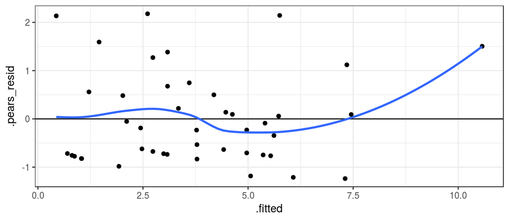

```r
M3_diag <- data.frame(.fitted = predict(M3, type = "response"),
                      .pears_resid = residuals(M3, type = "pearson"))
ggplot(M3_diag, aes(x = .fitted, y = .pears_resid)) + geom_point() +
  geom_hline(yintercept = 0) + geom_smooth(se = FALSE, method = "loess")
```

## Проверка на сверхдисперсию

Обратите внимание, у моделей с отрицательным биномиальным распределением добавляется еще один параметр

```r
pear_res <- resid(M3, type = "pearson") # Пирсоновские остатки
p <- length(coef(M3))  + 1             # число параметров в модели
N <- nrow(model.frame(M3))             # объем выборки
df <- N - p                            # число степеней свободы
Overdisp <- sum(pear_res^2) / df

Overdisp
```

```
## [1] 1.08
```

- Избыточности дисперсии нет

## Задание 3

Визуализируйте предсказания модели, основанной на отрицательном биномиальном распределении

```r
NewData <- ddply(
  .data = , .variables = .(), .fun = summarise,
  DiversityD_1 = )
NewData$Flowers = mean(pol$Flowers)
NewData$Hours = mean(pol$Hours)
# предсказанные значения
Predictions <- predict()
NewData$fit <- Predictions$fit
# стандартные ошибки
NewData$SE <- Predictions$se.fit
# доверительный интервал
NewData$upr <- NewData$fit + 1.96 * NewData$SE
NewData$lwr <- NewData$fit - 1.96 * NewData$SE

ggplot(NewData, aes(x = , y = , group = )) +
  geom_ribbon(aes(ymin = lwr, ymax = upr), alpha = 0.3) +
  geom_line() +
  geom_hline(yintercept = 0)
```

## Визуализируем предсказания модели

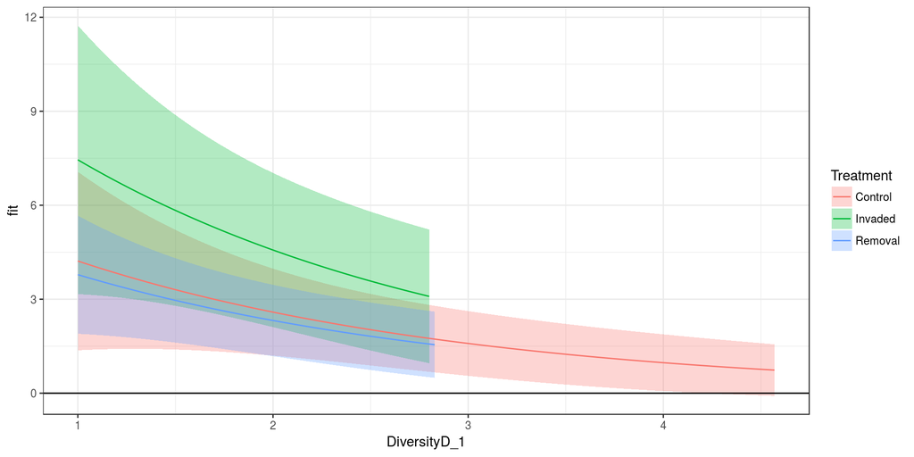

## Код для графика

```r
NewData <- ddply(.data = pol, .variables = .(Treatment),
    .fun = summarise, DiversityD_1 = seq(min(DiversityD_1),
        max(DiversityD_1), length = 100))
NewData$Flowers = mean(pol$Flowers)
NewData$Hours = mean(pol$Hours)
# предсказанные значения
Predictions <- predict(M3, newdata = NewData, se.fit = TRUE,
    type = "response")
NewData$fit <- Predictions$fit
# стандартные ошибки
NewData$SE <- Predictions$se.fit
# доверительный интервал
NewData$upr <- NewData$fit + 1.96 * NewData$SE
NewData$lwr <- NewData$fit - 1.96 * NewData$SE

ggplot(NewData, aes(x = DiversityD_1, y = fit, group = Treatment)) +
    geom_ribbon(aes(ymin = lwr, ymax = upr, fill = Treatment),
        alpha = 0.3) + geom_line(aes(colour = Treatment)) +
    geom_hline(yintercept = 0)
```

## Таким образом

1. Модели, основанные на неподходящем типе распределения, могут давать нереалистичные предсказанные значения.
2. В зависимости от того, как сконструирована модель, можно получить результаты, которые позволят сформулировать принципиально разные биологические выводы.

## Выбор оптимальной модели

## Какие факторы определяют супружескую неверность?

```r
data(Affairs, package = "AER")
af <- Affairs
```

Оригинальная работа: Fair, R.C. (1978). A Theory of Extramarital Affairs. Journal of Political Economy, 86, 45–61.

`affairs` - Количество внебрачных свзяей за последний год  
`gender` - пол  
`age` - возраст  
`yearsmarried` - сколько ле в браке  
`children` - наличие детей  
`religiousness` - уровеь религиозности  
`education` - уровень образования  
`rating` - самооценка ощущений от брака

## Задание 4

1. Постройте оптимальную модель, описывающую зависимость количества внебрачных связей в зависимости от пола, времени, проведенного в браке, наличия детей, уровня религиозности и уровня образованности.
2. Проверьте валидность данной модели

## Решение

```r
Mod <- glm(affairs ~ gender + yearsmarried + children + religiousness +
    education, data = af, family = "poisson")
# Результаты
summary(Mod)
```

```
##
## Call:
## glm(formula = affairs ~ gender + yearsmarried + children + religiousness +
##     education, family = "poisson", data = af)
##
## Deviance Residuals:
##    Min      1Q  Median      3Q     Max
## -3.327  -1.761  -1.329  -0.777   6.748
##
## Coefficients:
##               Estimate Std. Error z value Pr(>|z|)
## (Intercept)    0.84580    0.25843    3.27   0.0011 **
## gendermale     0.07652    0.07319    1.05   0.2957
## yearsmarried   0.09340    0.00775   12.06   <2e-16 ***
## childrenyes    0.04525    0.10492    0.43   0.6663
## religiousness -0.37135    0.02945  -12.61   <2e-16 ***
## education     -0.02043    0.01483   -1.38   0.1683
## ---
## Signif. codes:  0 '***' 0.001 '**' 0.01 '*' 0.05 '.' 0.1 ' ' 1
##
## (Dispersion parameter for poisson family taken to be 1)
##
##     Null deviance: 2925.5  on 600  degrees of freedom
## Residual deviance: 2605.3  on 595  degrees of freedom
## AIC: 3111
##
## Number of Fisher Scoring iterations: 6
```

## Проверка на избыточность дисперсии

```r
# Проверка на избыточность дисперсии
pear_res <- resid(Mod, type = "pearson") # Пирсоновские остатки
p <- length(coef(Mod))                   # число параметров в модели
N <- nrow(model.frame(Mod)) # объем выборки
df <- N - p       # число степеней свободы
Overdisp <- sum(pear_res^2) / df

Overdisp
```

```
## [1] 6.67
```

## Можно построить квази-пуассоновскую модель

Это грубое приближение

```r
Mod1 <- glm(affairs ~ gender + yearsmarried + children + religiousness +
    education, data = af, family = "quasipoisson")
# Результаты
summary(Mod1)
```

```
##
## Call:
## glm(formula = affairs ~ gender + yearsmarried + children + religiousness +
##     education, family = "quasipoisson", data = af)
##
## Deviance Residuals:
##    Min      1Q  Median      3Q     Max
## -3.327  -1.761  -1.329  -0.777   6.748
##
## Coefficients:
##               Estimate Std. Error t value  Pr(>|t|)
## (Intercept)     0.8458     0.6673    1.27      0.21
## gendermale      0.0765     0.1890    0.40      0.69
## yearsmarried    0.0934     0.0200    4.67 0.0000037 ***
## childrenyes     0.0452     0.2709    0.17      0.87
## religiousness  -0.3714     0.0760   -4.88 0.0000013 ***
## education      -0.0204     0.0383   -0.53      0.59
## ---
## Signif. codes:  0 '***' 0.001 '**' 0.01 '*' 0.05 '.' 0.1 ' ' 1
##
## (Dispersion parameter for quasipoisson family taken to be 6.67)
##
##     Null deviance: 2925.5  on 600  degrees of freedom
## Residual deviance: 2605.3  on 595  degrees of freedom
## AIC: NA
##
## Number of Fisher Scoring iterations: 6
```

## Строим модель, основанную на отрицательном биномиальном распределении

```r
Mod_nb <- glm.nb(affairs ~ gender + yearsmarried + children +
    religiousness + education, data = af)
Anova(Mod_nb)
```

```
## Analysis of Deviance Table (Type II tests)
##
## Response: affairs
##               LR Chisq Df Pr(>Chisq)
## gender            0.29  1       0.59
## yearsmarried     17.59  1   0.000027 ***
## children          1.19  1       0.28
## religiousness    17.23  1   0.000033 ***
## education         1.50  1       0.22
## ---
## Signif. codes:  0 '***' 0.001 '**' 0.01 '*' 0.05 '.' 0.1 ' ' 1
```

## Подбираем оптимальную модель

```r
Mod_nb_final <- step(Mod_nb, direction = "backward", trace = 0)
summary(Mod_nb_final)
```

```
##
## Call:
## glm.nb(formula = affairs ~ yearsmarried + religiousness, data = af,
##     init.theta = 0.1297897878, link = log)
##
## Deviance Residuals:
##    Min      1Q  Median      3Q     Max
## -1.013  -0.827  -0.707  -0.491   1.982
##
## Coefficients:
##               Estimate Std. Error z value   Pr(>|z|)
## (Intercept)     0.6037     0.3569    1.69      0.091 .
## yearsmarried    0.1156     0.0224    5.16 0.00000025 ***
## religiousness  -0.4468     0.1067   -4.19 0.00002841 ***
## ---
## Signif. codes:  0 '***' 0.001 '**' 0.01 '*' 0.05 '.' 0.1 ' ' 1
##
## (Dispersion parameter for Negative Binomial(0.13) family taken to be 1)
##
##     Null deviance: 366.31  on 600  degrees of freedom
## Residual deviance: 335.40  on 598  degrees of freedom
## AIC: 1481
##
## Number of Fisher Scoring iterations: 1
##
##
##               Theta:  0.1298
##           Std. Err.:  0.0142
##
##  2 x log-likelihood:  -1473.4200
```

## Диагностика модели

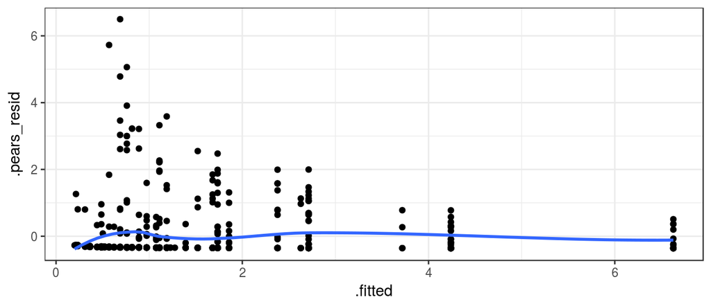

```r
Mod_nb_diag <- data.frame(
  af,
  .fitted = predict(Mod_nb_final, type = "response"),
  .pears_resid = residuals(Mod_nb, type = "pearson"))

ggplot(Mod_nb_diag, aes(x = .fitted, y = .pears_resid)) + geom_point() +
  geom_smooth(se = FALSE)
```

## Графики остатков от предикторов в модели и нет

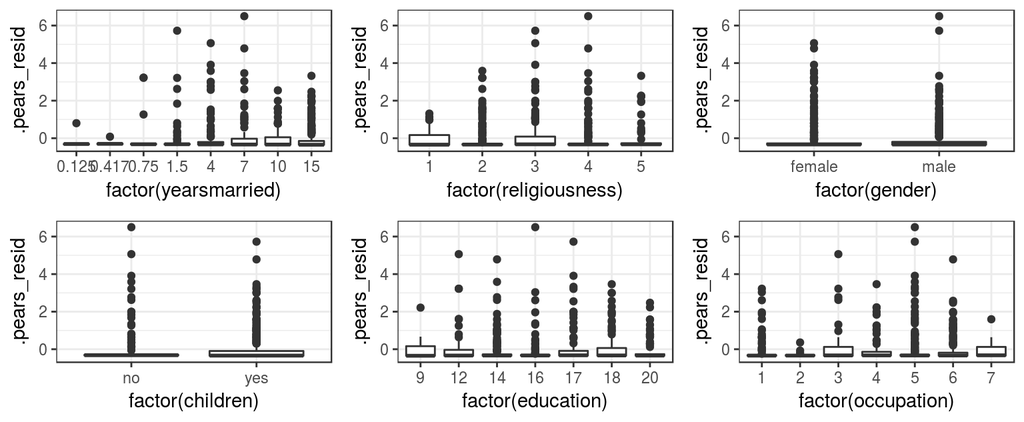

```r
gg_res <- ggplot(Mod_nb_diag, aes(y = .pears_resid)) +
  geom_boxplot()

grid.arrange(gg_res + aes(x = factor(yearsmarried)),
             gg_res + aes(x = factor(religiousness)),
             gg_res + aes(x = factor(gender)),
             gg_res + aes(x = factor(children)),
             gg_res + aes(x = factor(education)),
             gg_res + aes(x = factor(occupation)),
             nrow = 2)
```

## Проверим на избыточность дисперсии

```r
# Проверка на избыточность дисперсии
pear_res <- resid(Mod_nb_final, type = "pearson") # Пирсоновские остатки
p <- length(coef(Mod_nb_final)) + 1               # число параметров в модели
N <- nrow(model.frame(Mod_nb_final)) # объем выборки
df <- N - p       # число степеней свободы
Overdisp <- sum(pear_res^2) / df

Overdisp
```

```
## [1] 0.734
```

## Визуализируем предсказание модели

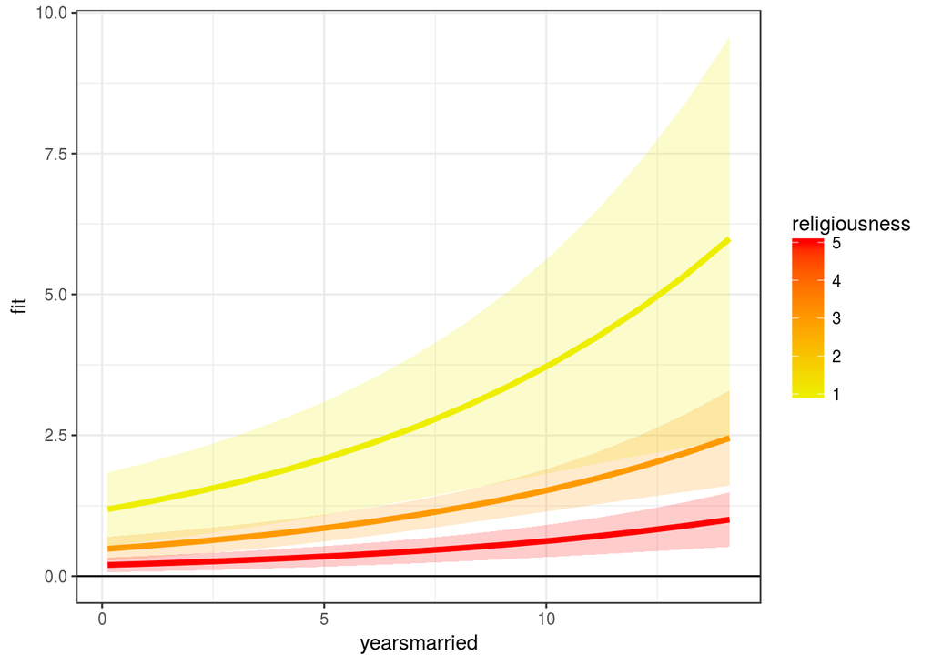

## Код для графика

```r
NewData <- expand.grid(yearsmarried = seq(min(af$yearsmarried),
    max(af$yearsmarried)), religiousness = seq(min(af$religiousness),
    max(af$religiousness), length.out = 3))

# предсказанные значения
Predictions <- predict(Mod_nb_final, newdata = NewData,
    se.fit = TRUE, type = "response")
NewData$fit <- Predictions$fit
# стандартные ошибки
NewData$SE <- Predictions$se.fit
# доверительный интервал
NewData$upr <- NewData$fit + 1.96 * NewData$SE
NewData$lwr <- NewData$fit - 1.96 * NewData$SE
# график предсказаний модели
ggplot(NewData, aes(x = yearsmarried, y = fit, group = religiousness)) +
    geom_ribbon(aes(ymin = lwr, ymax = upr, fill = religiousness),
        alpha = 0.2) + geom_line(aes(colour = religiousness),
    size = 1.5) + geom_hline(yintercept = 0) + scale_color_gradient(low = "yellow2",
    high = "red") + scale_fill_gradient(low = "yellow2",
    high = "red")
```

## Summary

- В случае счетных зависимых перменных (неотрицательных целочисленных величин) применяются модели, основанные на распределении Пуассона или отрицательном биномиальном распределении.
- Важным ограничением применения этих моделей является отсутствие избыточности дисперсии.
- Избыточность дисперсии может быть истинной и мнимой.
- При истинной избыточности дисперсии модель можно скорректировать, поcтроив квази-пуассоновскую модель (вводятся поправки для ошибок оценок коэффициентов модели).
- Другой подход — построение моделей, основанных на отрицательном биномиальном распределении.

## Что почитать

- Кабаков Р.И. R в действии. Анализ и визуализация данных на языке R. М.: ДМК Пресс, 2014.
- Zuur, A.F. et al. 2009. Mixed effects models and extensions in ecology with R. Statistics for biology and health. Springer, New York, NY.